# El Rosario, Baja California

*Este documento fue generado por el paquete [`MPAtools`](https://github.com/turfeffect/MPAtools), uno de los entregables del grupo TURFeffect. Los resultados presentados son una version preliminar del software que se esta desarrollando, y no recomendamos la toma de decisiones basado en la informacion aqui presentada*

*Acentos y caracteres especiales omitidos*

# Resumen

**Leyenda**

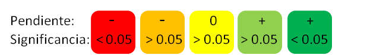

[output not shown]

# Ecologicos

## Peces

### Densidad

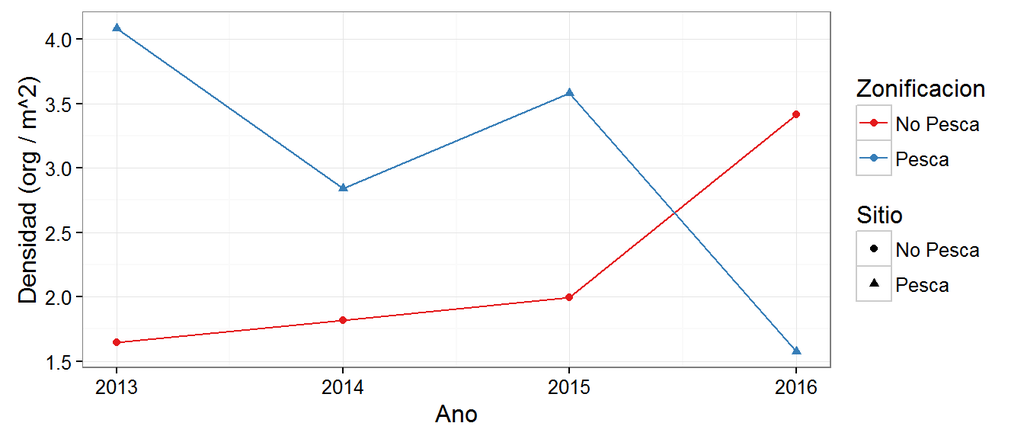

Densidad promedio de peces (org / m^2).

|  | Densidad (org / transecto) |
| --- | --- |
| Ano | -0.68<sup>+</sup> |
| Zona | -2,475.93<sup>++</sup> |
| **Ano:Zona** | 1.23<sup>++</sup> |
| Constante | 1,371.53<sup>+</sup> |
| R<sup>2</sup> | 0.75 |
| Residual Std. Error | 0.66 |
| F Statistic | 3.93 |
| *Note:* | +p < 0.1, ++p<0.05, +++p<0.001 |

### Riqueza

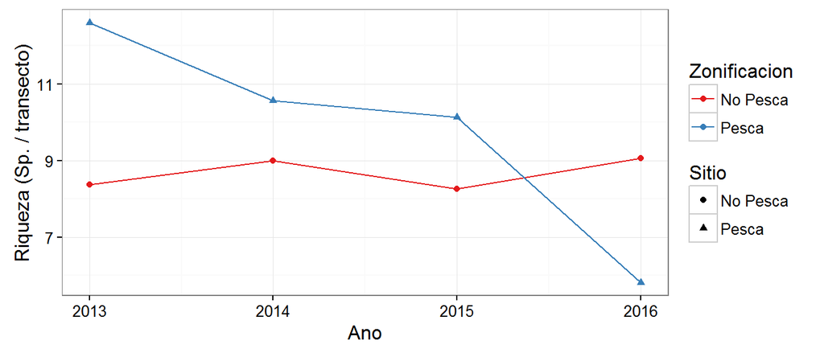

Riqueza promedio de peces (Sp / transecto).

|  | Riqueza (Sp. / transecto) |
| --- | --- |
| Ano | -2.08<sup>+++</sup> |
| Zona | -4,455.38<sup>++</sup> |
| **Ano:Zona** | 2.21<sup>++</sup> |
| Constante | 4,200.33<sup>+++</sup> |
| R<sup>2</sup> | 0.88 |
| Residual Std. Error | 0.90 |
| F Statistic | 9.95<sup>++</sup> |
| *Note:* | +p < 0.1, ++p<0.05, +++p<0.001 |

### Biomasa

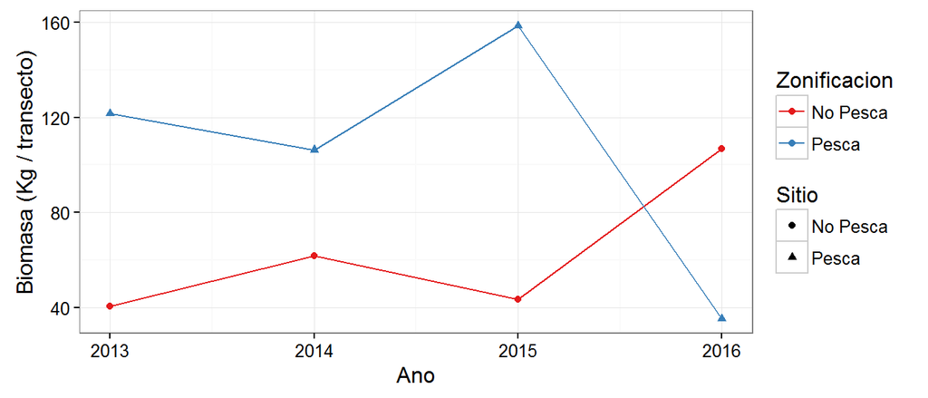

Biomasa promedio de peces (Kg / transecto).

|  | Biomasa (Kg / transecto) |
| --- | --- |
| Ano | -20.67 |
| Zona | -77,999.93 |
| **Ano:Zona** | 38.70 |
| Constante | 41,739.41 |
| R<sup>2</sup> | 0.51 |
| Residual Std. Error | 42.00 |
| F Statistic | 1.39 |
| *Note:* | +p < 0.1, ++p<0.05, +++p<0.001 |